# Travel Insurance Prediction

This notebook analyses Travel Insurance Prediction dataset downloaded from [Kaggle](https://www.kaggle.com/datasets/tejashvi14/travel-insurance-prediction-data).

Identifying characteristics of individuals interested in travel insurance is crucial for targeting new customers efficiently and saving resources.

## Goal

The goal of this project is to create a model that identifies clients that are most likely to buy travel insurance.

## Objectives

To achieve this goal, the following objectives have been established:

1. Download, load and clean the dataset.
2. Conduct exploratory data analysis and visualize data to identify underlying patterns.
3. Perform statistical inference to validate findings.
4. Apply linear machine learning models to predict which customers would be interested to buy travel insurance.
5. Summarize the results and provide recommendations.

## Libraries

```python
import matplotlib.pyplot as plt
import numpy as np
import pandas as pd
import seaborn as sns
from IPython.display import display
from itertools import combinations
from scipy.stats import chi2_contingency, pointbiserialr, spearmanr
from sklearn.dummy import DummyClassifier
from sklearn.ensemble import (
    GradientBoostingClassifier,
    RandomForestClassifier,
)
from sklearn.linear_model import LogisticRegression
from sklearn.metrics import (
    accuracy_score,
    classification_report,
    confusion_matrix,
    f1_score,
    precision_score,
    recall_score,
)
from sklearn.model_selection import GridSearchCV, train_test_split
from sklearn.neighbors import KNeighborsClassifier
from sklearn.preprocessing import StandardScaler
from sklearn.svm import SVC
from sklearn.tree import DecisionTreeClassifier
from xgboost import XGBClassifier
import warnings

warnings.filterwarnings("ignore")
```

```python
sns.set(style="darkgrid", font_scale=0.8)

warnings.filterwarnings("ignore")

pd.set_option("display.float_format", lambda x: "%.3f" % x)
```

## Dataset

```python
df = pd.read_csv(r"C:\Users\nacev\OneDrive\TravelInsurancePrediction.csv", index_col=0)
```

```python
df.head()
```

|  | Age | Employment Type | GraduateOrNot | AnnualIncome | FamilyMembers | ChronicDiseases | FrequentFlyer | EverTravelledAbroad | TravelInsurance |
| --- | --- | --- | --- | --- | --- | --- | --- | --- | --- |
| 0 | 31 | Government Sector | Yes | 400000 | 6 | 1 | No | No | 0 |
| 1 | 31 | Private Sector/Self Employed | Yes | 1250000 | 7 | 0 | No | No | 0 |
| 2 | 34 | Private Sector/Self Employed | Yes | 500000 | 4 | 1 | No | No | 1 |
| 3 | 28 | Private Sector/Self Employed | Yes | 700000 | 3 | 1 | No | No | 0 |
| 4 | 28 | Private Sector/Self Employed | Yes | 700000 | 8 | 1 | Yes | No | 0 |

```python
df.info()
```

```
<class 'pandas.core.frame.DataFrame'>
Int64Index: 1987 entries, 0 to 1986
Data columns (total 9 columns):
 #   Column               Non-Null Count  Dtype
---  ------               --------------  -----
 0   Age                  1987 non-null   int64
 1   Employment Type      1987 non-null   object
 2   GraduateOrNot        1987 non-null   object
 3   AnnualIncome         1987 non-null   int64
 4   FamilyMembers        1987 non-null   int64
 5   ChronicDiseases      1987 non-null   int64
 6   FrequentFlyer        1987 non-null   object
 7   EverTravelledAbroad  1987 non-null   object
 8   TravelInsurance      1987 non-null   int64
dtypes: int64(5), object(4)
memory usage: 155.2+ KB
```

The dataset consists of information about almost 2000 customers and includes 9 features, encompassing demographic, travel history, and health-related attributes:

**Age** - customer's age

**Employment Type** - sector in which the customer is employed

**Graduate** - indicates whether the customer is a college graduate

**AnnualIncome** - yearly income of the customer

**FamilyMembers** - number of members in customer's family

**ChronicDisease** - indicates whether the customer suffers from a major disease like diabetes, high blood pressure, or asthma

**FrequentFlyer** - derived data based on the customer's history of booking air tickets on at least 4 different instances between 2017 and 2019

**TravelledAbroad** - indicates whether the customer has traveled to a foreign country before

**TravelInsurance** - indicates whether the customer bought a travel insurance package during the introductory offering held in 2019

```python
for column in df.columns:
    num_unique = df[column].nunique()
    print(f"Number of unique values in {column}: {num_unique}")
```

```
Number of unique values in Age: 11
Number of unique values in Employment Type: 2
Number of unique values in GraduateOrNot: 2
Number of unique values in AnnualIncome: 30
Number of unique values in FamilyMembers: 8
Number of unique values in ChronicDiseases: 2
Number of unique values in FrequentFlyer: 2
Number of unique values in EverTravelledAbroad: 2
Number of unique values in TravelInsurance: 2
```

After calculating unique values for each feature, ChronicDiseases also looks like a categorical variable.

```python
df["ChronicDiseases"] = df["ChronicDiseases"].replace({0: "No", 1: "Yes"})
```

```python
df.isna().sum()
```

```
Age                    0
Employment Type        0
GraduateOrNot          0
AnnualIncome           0
FamilyMembers          0
ChronicDiseases        0
FrequentFlyer          0
EverTravelledAbroad    0
TravelInsurance        0
dtype: int64
```

```python
df.describe()
```

|  | Age | AnnualIncome | FamilyMembers | TravelInsurance |
| --- | --- | --- | --- | --- |
| count | 1987.000 | 1987.000 | 1987.000 | 1987.000 |
| mean | 29.650 | 932762.959 | 4.753 | 0.357 |
| std | 2.913 | 376855.685 | 1.610 | 0.479 |
| min | 25.000 | 300000.000 | 2.000 | 0.000 |
| 25% | 28.000 | 600000.000 | 4.000 | 0.000 |
| 50% | 29.000 | 900000.000 | 5.000 | 0.000 |
| 75% | 32.000 | 1250000.000 | 6.000 | 1.000 |
| max | 35.000 | 1800000.000 | 9.000 | 1.000 |

- Customers' ages predominantly range from 25 to 35 years old.
- The number of family members varies from 2 to 9.
- Yearly income spans from 300,000 to 1.8 million.

```python
duplicates = df[df.duplicated()]
num_duplicates = duplicates.shape[0]

print("Number of duplicate rows:", num_duplicates)
duplicates.head()
```

```
Number of duplicate rows: 738
```

|  | Age | Employment Type | GraduateOrNot | AnnualIncome | FamilyMembers | ChronicDiseases | FrequentFlyer | EverTravelledAbroad | TravelInsurance |
| --- | --- | --- | --- | --- | --- | --- | --- | --- | --- |
| 69 | 31 | Government Sector | No | 300000 | 4 | No | No | No | 0 |
| 103 | 26 | Private Sector/Self Employed | Yes | 1400000 | 5 | No | No | Yes | 1 |
| 117 | 31 | Government Sector | Yes | 400000 | 5 | No | No | No | 0 |
| 148 | 25 | Private Sector/Self Employed | Yes | 1400000 | 4 | No | No | Yes | 1 |
| 164 | 28 | Government Sector | Yes | 300000 | 6 | No | No | No | 0 |

While the dataset may contain entries that appear to be duplicates, it is entirely possible for some clients to share the same parameters. Therefore, these entries will be left unchanged.

## Exploratory Data Analysis

In this section the dataset is examined to gain insights and understand its characteristics.

### Overview

```python
df["TravelInsurance"] = df["TravelInsurance"].replace({0: "No", 1: "Yes"})
```

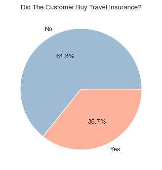

```python
travel_insurance_counts = df["TravelInsurance"].value_counts()

plt.figure(figsize=(4, 4))
plt.pie(
    travel_insurance_counts,
    labels=travel_insurance_counts.index,
    autopct="%1.1f%%",
    colors=["#9dbcd4", "#ffb19a"],
)
plt.title("Did The Customer Buy Travel Insurance?")
plt.show()
```

It can be observed that almost 36% clients bought travel insurance over the analyzed period, therefore the dataset is slightly imbalanced.

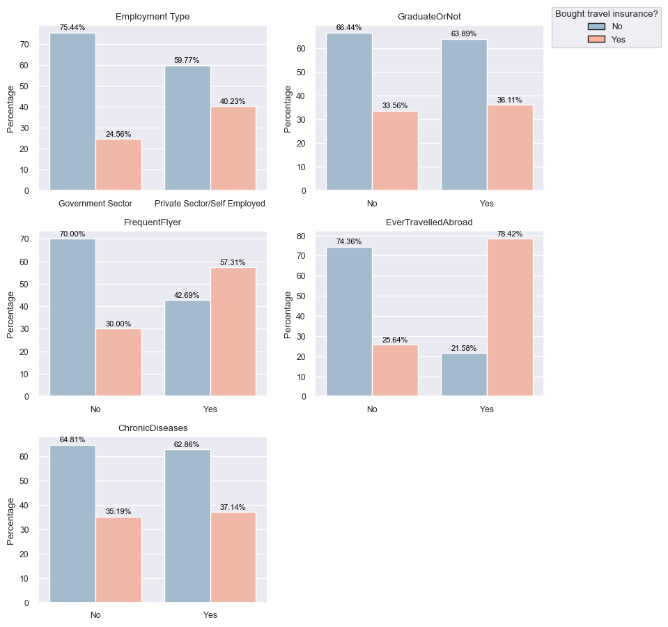

```python
categorical_features = [
    "Employment Type",
    "GraduateOrNot",
    "FrequentFlyer",
    "EverTravelledAbroad",
    "ChronicDiseases",
]

fig, axes = plt.subplots(3, 2, figsize=(8, 9))
custom_palette = ["#9dbcd4", "#ffb19a"]

for feature, ax in zip(categorical_features, axes.flatten()):
    cross_tab = pd.crosstab(df[feature], df["TravelInsurance"], normalize="index") * 100
    cross_tab = cross_tab.reset_index()

    melted_df = pd.melt(
        cross_tab,
        id_vars=[feature],
        var_name="TravelInsurance",
        value_name="Percentage",
    )

    sns.barplot(
        data=melted_df,
        x=feature,
        y="Percentage",
        hue="TravelInsurance",
        ax=ax,
        palette=custom_palette,
    )

    ax.set_title(f"{feature}")
    ax.set_xlabel("")
    ax.set_ylabel("Percentage")

    for p in ax.patches:
        ax.annotate(
            f"{p.get_height():.2f}%",
            (p.get_x() + p.get_width() / 2.0, p.get_height()),
            ha="center",
            va="center",
            fontsize=8,
            color="black",
            xytext=(0, 5),
            textcoords="offset points",
        )

    ax.legend_ = None

handles = [
    plt.Rectangle((0, 0), 1, 1, color="#9dbcd4", ec="k"),
    plt.Rectangle((0, 0), 1, 1, color="#ffb19a", ec="k"),
]
labels = ["No", "Yes"]

fig.legend(
    handles,
    labels,
    loc="upper right",
    title="Bought travel insurance?",
    bbox_to_anchor=(1.2, 1),
)

plt.delaxes(axes[2, 1])

plt.tight_layout()
plt.show()
```

A grid of bar plots illustrates the distribution of individuals who have purchased travel insurance based on various categorical features.

Interestingly, the distribution among individuals with and without chronic diseases, as well as between graduates and non-graduates, appears quite similar. Roughly a third of individuals opt to buy travel insurance regardless of their chronic disease status or educational background.

However, the situation differs with the other three categorical values. For instance, 40% of individuals employed in the private sector or self-employed purchased insurance, whereas only 25% of those in the government sector did so. Additionally, 57% of frequent flyers chose to buy insurance, compared to only 30% of those flying less than 4 times. Furthermore, a past history of traveling significantly increased the likelihood of purchasing insurance - 78% of past travelers bought insurance, while only 26% of those who had never traveled did so.

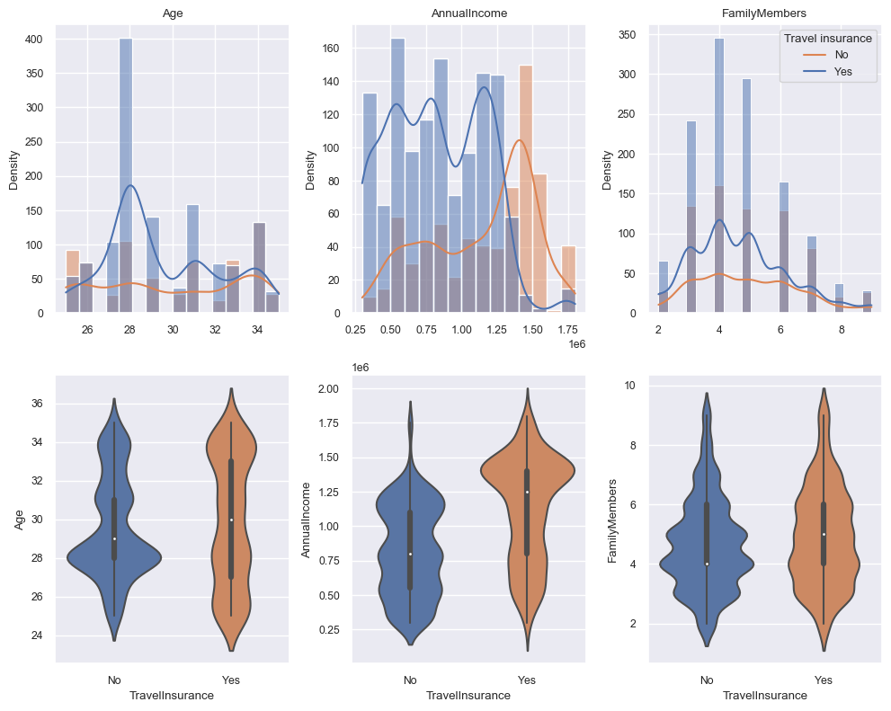

```python
numerical_features = ["Age", "AnnualIncome", "FamilyMembers"]

fig, axes = plt.subplots(2, 3, figsize=(10, 8))

for i, feature in enumerate(numerical_features):

    sns.histplot(data=df, x=feature, hue="TravelInsurance", kde=True, ax=axes[0, i])
    axes[0, i].set_title(f"{feature}")
    axes[0, i].set_xlabel("")
    axes[0, i].set_ylabel("Density")

    if i != 2 and axes[0, i].get_legend() is not None:
        axes[0, i].get_legend().remove()

    sns.violinplot(data=df, x="TravelInsurance", y=feature, ax=axes[1, i])
    axes[1, i].set_title("")
    axes[1, i].set_xlabel("TravelInsurance")
    axes[1, i].set_ylabel(feature)

    if i != 2 and axes[1, i].get_legend() is not None:
        axes[1, i].get_legend().remove()

axes[0, 2].legend(title="Travel insurance", labels=["No", "Yes"], loc="upper right")

plt.tight_layout()
plt.show()
```

Visualization of the relationship between numerical features and the purchase of travel insurance indicates that individuals with higher income are more inclined to buy travel insurance. However, the differences in age and the number of family members between those who bought travel insurance and those who did not appear to be less significant.

### Correlations

To explore the relationships between independent variables and the dependent variable, correlations will be calculated. Additionally, a new feature will be derived by calculating the income per family member, which is obtained by dividing the annual income by the number of family members.

```python
df.replace({"No": 0, "Yes": 1}, inplace=True)
df.replace({"Government Sector": 0, "Private Sector/Self Employed": 1}, inplace=True)
```

```python
df['IncomePerFamilyMember'] = df['AnnualIncome'] / df['FamilyMembers']
```

```python
correlations = {}

for var in [
    "Employment Type",
    "GraduateOrNot",
    "ChronicDiseases",
    "FrequentFlyer",
    "EverTravelledAbroad",
]:

    contingency_table = pd.crosstab(df[var], df["TravelInsurance"])
    chi2, _, _, _ = chi2_contingency(contingency_table)

    if contingency_table.shape == (2, 2):
        phi_coefficient = np.sqrt(chi2 / df.shape[0])
    else:
        n = contingency_table.sum().sum()
        phi2 = chi2 / n
        min_dim = min(contingency_table.shape) - 1
        phi_coefficient = np.sqrt(phi2 / min_dim)

    correlations[var] = phi_coefficient

for var in ["Age", "AnnualIncome", "IncomePerFamilyMember", "FamilyMembers"]:
    corr, _ = pointbiserialr(df[var], df["TravelInsurance"])
    correlations[var] = corr

sorted_correlations = sorted(
    correlations.items(), key=lambda x: abs(x[1]), reverse=True
)

print("Correlations with TravelInsurance from highest to lowest:")
for var, corr in sorted_correlations:
    print(f"  {var}: {corr:.3f}")
```

```
Correlations with TravelInsurance from highest to lowest:
  EverTravelledAbroad: 0.432
  AnnualIncome: 0.397
  IncomePerFamilyMember: 0.249
  FrequentFlyer: 0.231
  Employment Type: 0.147
  FamilyMembers: 0.080
  Age: 0.061
  GraduateOrNot: 0.017
  ChronicDiseases: 0.017
```

Correlation coefficients were calculated depending on the variable type. The results are consistent with what was shown in the previous charts: there is almost no correlation between ChronicDiseases, GraduateOrNot, Age, and FamilyMembers variables and TravelInsurance. Weak positive correlations are observed between Employment Type, FrequentFlyer, and IncomePerFamilyMember variables and TravelInsurance, while moderate positive correlations exist between AnnualIncome and EverTravelledAbroad with TravelInsurance.

The hypothesis testing will be conducted to determine if these correlations are statistically significant.

## Statistical Inference

Further, statistical inference will be performed.

**Target Population:** 1,987 individuals that were offered travel insurance in 2019.

**Significance Level**: The significance level (α) is chosen to be 0.05.

### First Hypothesis

**Null Hypothesis (H0):** There is no significant association between the categorical independent variables.

**Alternative Hypothesis (H1):** There is a significant association between the categorical independent variables.

```python
variables = [
    "EverTravelledAbroad",
    "FrequentFlyer",
    "Employment Type",
    "GraduateOrNot",
    "ChronicDiseases",
]

variable_combinations = combinations(variables, 2)

for var1, var2 in variable_combinations:
    contingency_table = pd.crosstab(df[var1], df[var2])
    chi2, p_value, _, _ = chi2_contingency(contingency_table)

    if contingency_table.shape == (2, 2):
        phi_coefficient = np.sqrt(chi2 / df.shape[0])
    else:
        n = contingency_table.sum().sum()
        phi2 = chi2 / n
        min_dim = min(contingency_table.shape) - 1
        phi_coefficient = np.sqrt(phi2 / min_dim)

    print(f"Variables: {var1}-{var2}")
    print(f"Chi-square statistic: {chi2:.3f}")
    print(f"P-value: {p_value:.3f}")
    print(f"Phi coefficient / Cramer's V: {phi_coefficient:.3f}")
    print("\n")
```

```
Variables: EverTravelledAbroad-FrequentFlyer
Chi-square statistic: 151.102
P-value: 0.000
Phi coefficient / Cramer's V: 0.276


Variables: EverTravelledAbroad-Employment Type
Chi-square statistic: 64.153
P-value: 0.000
Phi coefficient / Cramer's V: 0.180


Variables: EverTravelledAbroad-GraduateOrNot
Chi-square statistic: 7.366
P-value: 0.007
Phi coefficient / Cramer's V: 0.061


Variables: EverTravelledAbroad-ChronicDiseases
Chi-square statistic: 0.780
P-value: 0.377
Phi coefficient / Cramer's V: 0.020


Variables: FrequentFlyer-Employment Type
Chi-square statistic: 40.306
P-value: 0.000
Phi coefficient / Cramer's V: 0.142


Variables: FrequentFlyer-GraduateOrNot
Chi-square statistic: 1.383
P-value: 0.240
Phi coefficient / Cramer's V: 0.026


Variables: FrequentFlyer-ChronicDiseases
Chi-square statistic: 3.562
P-value: 0.059
Phi coefficient / Cramer's V: 0.042


Variables: Employment Type-GraduateOrNot
Chi-square statistic: 31.330
P-value: 0.000
Phi coefficient / Cramer's V: 0.126


Variables: Employment Type-ChronicDiseases
Chi-square statistic: 0.211
P-value: 0.646
Phi coefficient / Cramer's V: 0.010


Variables: GraduateOrNot-ChronicDiseases
Chi-square statistic: 0.590
P-value: 0.442
Phi coefficient / Cramer's V: 0.017
```

Furthermore, a weak but significant association was found between frequent flyer status and employment type, implying that employment type may impact the likelihood of being a frequent flyer. Additionally, the association between employment type and graduate status was also found to be weak but significant, suggesting that individuals' employment type may be related to their educational background.

### Second Hypothesis

**Null Hypothesis (H0):** There is no significant correlation between categorical independent variables and the dependent variable.

**Alternative Hypothesis (H1):** There is a significant correlation between categorical independent variables and the dependent variable.

```python
for categorical_var in variables:
    contingency_table = pd.crosstab(df["TravelInsurance"], df[categorical_var])
    chi2, p_value, _, _ = chi2_contingency(contingency_table)

    n = contingency_table.sum().sum()
    phi2 = chi2 / n
    min_dim = min(contingency_table.shape) - 1
    cramer_v = np.sqrt(phi2 / min_dim)

    print(f"Variable: {categorical_var}")
    print(f"Chi-square statistic: {chi2:.3f}")
    print(f"P-value: {p_value:.3f}")
    print(f"Cramer's V: {cramer_v:.3f}")
    print("\n")
```

```
Variable: EverTravelledAbroad
Chi-square statistic: 370.560
P-value: 0.000
Cramer's V: 0.432


Variable: FrequentFlyer
Chi-square statistic: 105.857
P-value: 0.000
Cramer's V: 0.231


Variable: Employment Type
Chi-square statistic: 42.754
P-value: 0.000
Cramer's V: 0.147


Variable: GraduateOrNot
Chi-square statistic: 0.606
P-value: 0.436
Cramer's V: 0.017


Variable: ChronicDiseases
Chi-square statistic: 0.575
P-value: 0.448
Cramer's V: 0.017
```

### Third Hypothesis

**Null Hypothesis (H0):** There is no significant correlation between continuous independent variables and the dependent variable.

**Alternative Hypothesis (H1):** There is a significant correlation between continuous independent variables and the dependent variable.

```python
continuous_variables = [
    "Age",
    "AnnualIncome",
    "IncomePerFamilyMember",
]

dependent_variable = "TravelInsurance"

for continuous_var in continuous_variables:
    correlation_coefficient, p_value = pointbiserialr(
        df[dependent_variable], df[continuous_var]
    )

    n = len(df[continuous_var])
    margin_of_error = 1.96 / np.sqrt(n)
    lower_ci, upper_ci = (
        correlation_coefficient - margin_of_error,
        correlation_coefficient + margin_of_error,
    )

    print(f"Variable: {continuous_var}")
    print(f"Point-Biserial Correlation Coefficient: {correlation_coefficient:.3f}")
    print(f"95% Confidence Interval: ({lower_ci:.3f}, {upper_ci:.3f})")
    print(f"P-Value: {p_value:.3f}")
    print("\n")
```

```
Variable: Age
Point-Biserial Correlation Coefficient: 0.061
95% Confidence Interval: (0.017, 0.105)
P-Value: 0.006


Variable: AnnualIncome
Point-Biserial Correlation Coefficient: 0.397
95% Confidence Interval: (0.353, 0.441)
P-Value: 0.000


Variable: IncomePerFamilyMember
Point-Biserial Correlation Coefficient: 0.249
95% Confidence Interval: (0.205, 0.293)
P-Value: 0.000
```

## Statistical Modeling

This section aims to build a model that could accurately predict which individuals would buy travel insurance.

### Data Preparation

The data has been prepared for statistical modeling by partitioning it into training and testing sets. Additionally, the features have been scaled to ensure uniformity and facilitate accurate model training and evaluation.

#### Train-Test Split

```python
X = df.drop(["TravelInsurance"], axis=1)
y = df["TravelInsurance"]

(X_train, X_test, y_train, y_test) = train_test_split(
    X, y, test_size=0.3, random_state=16
)
```

#### Standard Scaling

```python
scaler = StandardScaler()
X_train_scaled = scaler.fit_transform(X_train)
X_test_scaled = scaler.transform(X_test)
```

### Model Training and Evaluation

#### Benchmark Classifier

```python
dummy_classifier = DummyClassifier(strategy="stratified")
dummy_classifier.fit(X_train_scaled, y_train)
y_pred_dummy = dummy_classifier.predict(X_test_scaled)

print("Classification Report for Dummy Classifier:")
print(classification_report(y_test, y_pred_dummy))
```

```
Classification Report for Dummy Classifier:
              precision    recall  f1-score   support

           0       0.62      0.67      0.64       370
           1       0.39      0.34      0.36       227

    accuracy                           0.54       597
   macro avg       0.50      0.50      0.50       597
weighted avg       0.53      0.54      0.54       597
```

The benchmark classifier, implemented using the DummyClassifier with a "stratified" strategy, serves as a baseline model to evaluate the performance of more complex classifiers.

With an accuracy of 54%, the model demonstrates limited predictive power, as reflected in the precision, recall, and F1-scores, which indicate that the classifier performs only slightly better than random chance.

Notably, the recall for class 1 (representing individuals who purchased travel insurance) is particularly low at 34%, indicating that the classifier struggles to correctly identify customers who bought travel insurance. Given the importance of correctly identifying potential customers for travel insurance, improving recall will be a key focus in optimizing the classifier's performance.

#### Model Selection

```python
classifiers = {
    "Logistic Regression": LogisticRegression(),
    "K-Nearest Neighbors": KNeighborsClassifier(),
    "Decision Tree": DecisionTreeClassifier(),
    "Random Forest": RandomForestClassifier(),
    "XGBoost": XGBClassifier(),
    "Gradient Boosting": GradientBoostingClassifier(),
    "Support Vector Classifier": SVC(),
}

for name, classifier in classifiers.items():
    classifier.fit(X_train_scaled, y_train)
    y_pred = classifier.predict(X_train_scaled)

    accuracy = accuracy_score(y_train, y_pred)
    precision = precision_score(y_train, y_pred)
    recall = recall_score(y_train, y_pred)
    f1 = f1_score(y_train, y_pred)

    print(f"{name}:")
    print(f"  Accuracy: {accuracy:.2f}")
    print(f"  Precision: {precision:.2f}")
    print(f"  Recall: {recall:.2f}")
    print(f"  F1-score: {f1:.2f}")
    print("\n")
```

```
Logistic Regression:
  Accuracy: 0.77
  Precision: 0.79
  Recall: 0.46
  F1-score: 0.58


K-Nearest Neighbors:
  Accuracy: 0.84
  Precision: 0.84
  Recall: 0.67
  F1-score: 0.75


Decision Tree:
  Accuracy: 0.92
  Precision: 0.97
  Recall: 0.80
  F1-score: 0.88


Random Forest:
  Accuracy: 0.92
  Precision: 0.94
  Recall: 0.83
  F1-score: 0.88


XGBoost:
  Accuracy: 0.91
  Precision: 0.93
  Recall: 0.80
  F1-score: 0.86


Gradient Boosting:
  Accuracy: 0.85
  Precision: 0.93
  Recall: 0.60
  F1-score: 0.73


Support Vector Classifier:
  Accuracy: 0.83
  Precision: 0.89
  Recall: 0.58
  F1-score: 0.71
```

In the model selection phase, several classifiers were trained and evaluated using the training dataset. Each classifier was trained on the scaled training data, and then evaluated based on various performance metrics, including accuracy, precision, recall, and F1-score.

Among these classifiers, the Decision Tree and Random Forest models demonstrated promising results with high accuracy, precision, and recall scores. However, the goal is to further optimize the recall score. Hence, the Decision Tree and Random Forest classifiers will be selected for further hyperparameter tuning to enhance their recall performance.

#### Hyperparameter Tuning

```python
param_grid = {
    "max_depth": [None, 10, 20, 50],
    "min_samples_split": [2, 5, 10, 20],
    "min_samples_leaf": [1, 2, 4, 10],
    "max_features": ["auto", "sqrt", "log2"],
}

dt_classifier = DecisionTreeClassifier(random_state=16)

grid_search = GridSearchCV(dt_classifier, param_grid, cv=5, scoring="recall")
grid_search.fit(X_train_scaled, y_train)

best_params_tree = grid_search.best_params_
best_score_tree = grid_search.best_score_

print("Best Parameters:", best_params_tree)
print("Best Recall Score:", best_score_tree)
```

```
Best Parameters: {'max_depth': None, 'max_features': 'auto', 'min_samples_leaf': 4, 'min_samples_split': 20}
Best Recall Score: 0.6253436426116837
```

```python
param_grid_forest = {
    "n_estimators": [10, 20, 50, 100],
    "max_depth": [None, 1, 5, 10, 20],
    "min_samples_split": [2, 5, 10],
    "bootstrap": [True, False],
}

rf_classifier = RandomForestClassifier(random_state=16)

grid_search = GridSearchCV(rf_classifier, param_grid_forest, cv=5, scoring="recall")
grid_search.fit(X_train_scaled, y_train)

best_params_forest = grid_search.best_params_
best_score_forest = grid_search.best_score_

print("Best Parameters:", best_params_forest)
print("Best Score:", best_score_forest)
```

```
Best Parameters: {'bootstrap': True, 'max_depth': None, 'min_samples_split': 2, 'n_estimators': 10}
Best Score: 0.6439218213058419
```

In the next step of the process, hyperparameter tuning was performed for the Decision Tree and Random Forest classifiers using grid search cross-validation.

For the Decision Tree classifier, the grid search identified the best combination of hyperparameters and achieved best recall score of approximately 0.625. Similarly, for the Random Forest classifier, best recall score of around 0.644.

The recall scores obtained after hyperparameter tuning are notably lower compared to the recall scores obtained before tuning. This decrease in recall could be attributed to several factors - the initial models might have overfit the training data, the choice of scoring metric during grid search cross-validation can also impact the performance of the tuned models, and the complexity of the dataset and the inherent variability in the data could also contribute to differences in performance before and after tuning.

#### Feature Importances

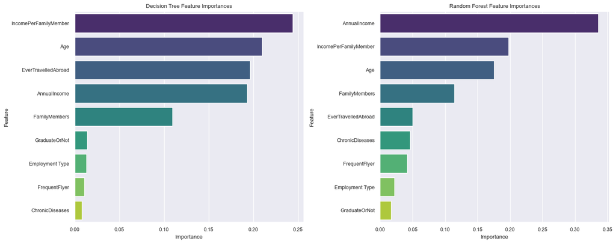

```python
# Decision Tree Classifier Feature Importance
dt_classifier_best = DecisionTreeClassifier(**best_params_tree, random_state=16)
dt_classifier_best.fit(X_train_scaled, y_train)

feature_importances_dt = dt_classifier_best.feature_importances_

importance_df_dt = pd.DataFrame(
    {"Feature": X_train.columns, "Importance": feature_importances_dt}
)

importance_df_dt = importance_df_dt.sort_values(by="Importance", ascending=False)

# Random Forest Classifier Feature Importance
rf_classifier_best = RandomForestClassifier(**best_params_forest, random_state=16)
rf_classifier_best.fit(X_train_scaled, y_train)

feature_importances_rf = rf_classifier_best.feature_importances_

importance_df_rf = pd.DataFrame(
    {"Feature": X_train.columns, "Importance": feature_importances_rf}
)

importance_df_rf = importance_df_rf.sort_values(by="Importance", ascending=False)

# Plotting
fig, axes = plt.subplots(1, 2, figsize=(15, 6))

sns.barplot(
    data=importance_df_dt, x="Importance", y="Feature", palette="viridis", ax=axes[0]
)
axes[0].set_xlabel("Importance")
axes[0].set_ylabel("Feature")
axes[0].set_title("Decision Tree Feature Importances")

sns.barplot(
    data=importance_df_rf, x="Importance", y="Feature", palette="viridis", ax=axes[1]
)
axes[1].set_xlabel("Importance")
axes[1].set_ylabel("Feature")
axes[1].set_title("Random Forest Feature Importances")

plt.tight_layout()
plt.show()
```

The feature importance charts indicate the contribution of each feature to the decision-making process of the model. In Decision Tree's case, IncomePerFamilyMember has the highest importance score of 0.244, followed closely by Age with a score of 0.210. EverTravelledAbroad and AnnualIncome also have relatively high importance scores of 0.197 and 0.193, respectively. Other features contribute less to the model's decision-making process.

For Random Forest classifier, AnnualIncome emerges as the most important feature with an importance score of 0.336, followed by IncomePerFamilyMember with a score of 0.198 and Age with a score of 0.175. FamilyMembers also demonstrates substantial importance with a score of 0.114.

Interestingly, the importance rankings for some features differ between the Decision Tree and Random Forest models, indicating differences in the feature importance assessment methods employed by each algorithm.

#### Model Evaluation

First, the analysis is conducted on the test set with both the Decision Tree Classifier and the Random Forest Classifier evaluated. Subsequently, the models were re-evaluated with only the important features retained.

```python
def report_classifier_performance(
    classifier, X_train_scaled, y_train, X_test_scaled, y_test
):
    classifier.fit(X_train_scaled, y_train)

    y_pred = classifier.predict(X_test_scaled)

    print("Classification Report on Test Set:")
    print(classification_report(y_test, y_pred))


dt_classifier = DecisionTreeClassifier(**best_params_tree, random_state=16)

print("Decision Tree Classifier:")
report_classifier_performance(
    dt_classifier, X_train_scaled, y_train, X_test_scaled, y_test
)

rf_classifier = RandomForestClassifier(**best_params_forest, random_state=16)

print("Random Forest Classifier:")
report_classifier_performance(
    rf_classifier, X_train_scaled, y_train, X_test_scaled, y_test
)
```

```
Decision Tree Classifier:
Classification Report on Test Set:
              precision    recall  f1-score   support

           0       0.80      0.92      0.86       370
           1       0.83      0.62      0.71       227

    accuracy                           0.81       597
   macro avg       0.82      0.77      0.78       597
weighted avg       0.81      0.81      0.80       597

Random Forest Classifier:
Classification Report on Test Set:
              precision    recall  f1-score   support

           0       0.78      0.89      0.83       370
           1       0.76      0.60      0.67       227

    accuracy                           0.78       597
   macro avg       0.77      0.74      0.75       597
weighted avg       0.78      0.78      0.77       597
```

The classification reports provide an overview of the performance of the Decision Tree and Random Forest classifiers on the test set.

The Decision Tree outperforms the Random Forest for predicting the positive class (purchasing travel insurance). The recall for class 1 is 0.62 for the Decision Tree, while it is 0.60 for the Random Forest.

```python
selected_features_dt = [
    "AnnualIncome",
    "Age",
    "EverTravelledAbroad",
    "FamilyMembers",
    "IncomePerFamilyMember",
]

selected_features_rf = ["AnnualIncome", "Age", "FamilyMembers", "IncomePerFamilyMember"]

selected_feature_indices_dt = [
    X_train.columns.get_loc(feature) for feature in selected_features_dt
]
selected_feature_indices_rf = [
    X_train.columns.get_loc(feature) for feature in selected_features_rf
]

X_train_scaled_dt = X_train_scaled[:, selected_feature_indices_dt]
X_test_scaled_dt = X_test_scaled[:, selected_feature_indices_dt]

X_train_scaled_rf = X_train_scaled[:, selected_feature_indices_rf]
X_test_scaled_rf = X_test_scaled[:, selected_feature_indices_rf]

dt_classifier_selected = DecisionTreeClassifier(**best_params_tree, random_state=16)

print("Decision Tree Classifier with Selected Features:")
report_classifier_performance(
    dt_classifier_selected, X_train_scaled_dt, y_train, X_test_scaled_dt, y_test
)

rf_classifier_selected = RandomForestClassifier(**best_params_forest, random_state=16)

print("Random Forest Classifier with Selected Features:")
report_classifier_performance(
    rf_classifier_selected, X_train_scaled_rf, y_train, X_test_scaled_rf, y_test
)
```

```
Decision Tree Classifier with Selected Features:
Classification Report on Test Set:
              precision    recall  f1-score   support

           0       0.79      0.92      0.85       370
           1       0.82      0.59      0.69       227

    accuracy                           0.80       597
   macro avg       0.80      0.76      0.77       597
weighted avg       0.80      0.80      0.79       597

Random Forest Classifier with Selected Features:
Classification Report on Test Set:
              precision    recall  f1-score   support

           0       0.80      0.90      0.85       370
           1       0.79      0.63      0.70       227

    accuracy                           0.80       597
   macro avg       0.80      0.76      0.77       597
weighted avg       0.80      0.80      0.79       597
```

After selecting only the important features, the changes in results are minimal. However, now the Random Forest Classifier outperforms the Decision Tree Classifier.

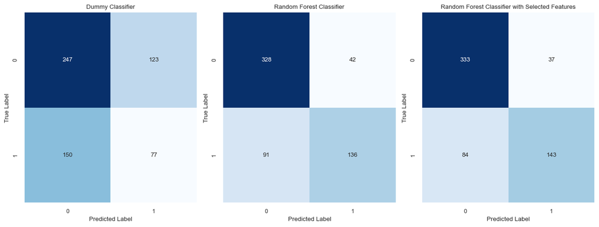

```python
fig, axes = plt.subplots(1, 3, figsize=(13, 5))

# Dummy Classifier
dummy_cm = confusion_matrix(y_test, y_pred_dummy)
sns.heatmap(dummy_cm, annot=True, fmt="d", cmap="Blues", cbar=False, ax=axes[0])
axes[0].set_title("Dummy Classifier")
axes[0].set_xlabel("Predicted Label")
axes[0].set_ylabel("True Label")

# Random Forest Classifier
rf_cm = confusion_matrix(y_test, rf_classifier.predict(X_test_scaled))
sns.heatmap(rf_cm, annot=True, fmt="d", cmap="Blues", cbar=False, ax=axes[1])
axes[1].set_title("Random Forest Classifier")
axes[1].set_xlabel("Predicted Label")
axes[1].set_ylabel("True Label")

# Random Forest Classifier with Selected Features
rf_selected_cm = confusion_matrix(y_test, rf_classifier_selected.predict(X_test_scaled_rf))
sns.heatmap(rf_selected_cm, annot=True, fmt="d", cmap="Blues", cbar=False, ax=axes[2])
axes[2].set_title("Random Forest Classifier with Selected Features")
axes[2].set_xlabel("Predicted Label")
axes[2].set_ylabel("True Label")

plt.tight_layout()
plt.show()
```

## PowerBI Dashboard

Finally, a dashboard using PowerBI was created.

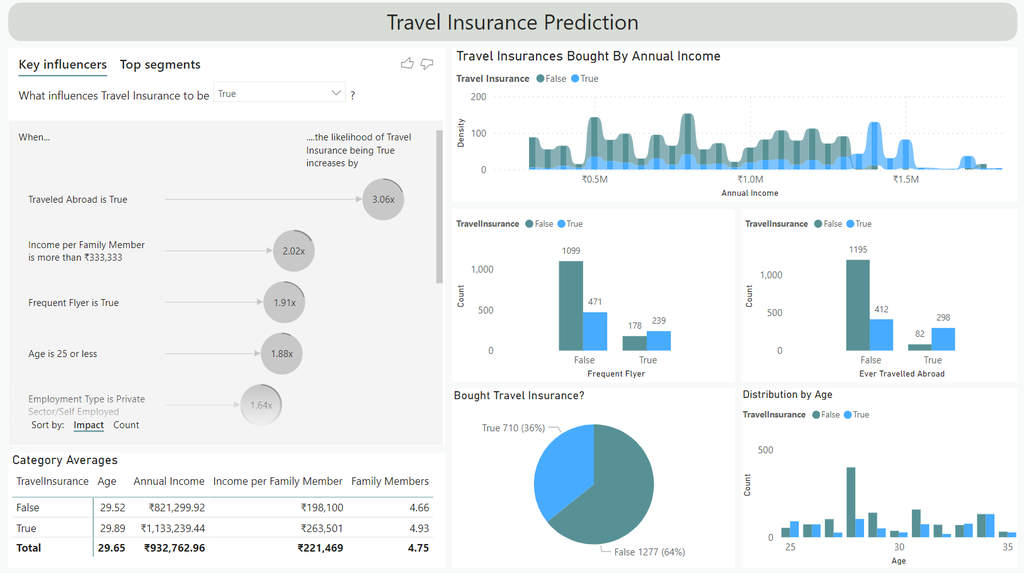

## Summary and Recommendations

### Summary of the Findings

**Exploratory Data Analysis**

- The dataset contains information on nearly 2000 customers, encompassing demographic, travel history, and health-related attributes. Key features include age, employment type, graduate status, annual income, family size, chronic disease status, frequent flyer status, and travel history.
- The dataset contains duplicate entries, which were retained due to the possibility of clients sharing similar parameters.
- Approximately 36% of clients purchased travel insurance, indicating a slight imbalance in the dataset.
- While chronic disease status and graduate status show similar purchase rates, employment type, frequent flyer status, and travel history significantly influence insurance purchases. Higher income individuals are more likely to buy insurance.
- Correlation analysis confirms these observations, with weak to moderate positive correlations between insurance purchase and employment type, frequent flyer status, income per family member, annual income, and travel history.

**Statistical Inference**

**Statistical Modeling**

- The benchmark classifier, with an accuracy of 54%, demonstrates limited effectiveness, barely surpassing random chance. Notably, its recall for positive instances is particularly low at 34%.
- More complex classifiers such as Decision Tree and Random Forest exhibited promising results, but with room for improvement in recall.
- Hyperparameter tuning was conducted to optimize model performance, resulting in a decrease in recall scores.
- Based on the feature importance analysis, the most important features varied between the classifiers, although income, income per family member and age were significant in both.
- Despite minor changes in performance after retaining only important features, the Random Forest Classifier emerged as the better performer.

### Recommendations for Further Analysis

To gain deeper insights and enhance the analysis, the following steps could be considered:

1. Address class imbalance using resampling techniques.
2. Explore feature engineering to create new variables or modify existing ones, potentially improving model performance.
3. Collect more data - expand the feature set by introducing additional variables or increasing the period of the analysis.
4. Cluster the clients based on their features.